# Datathon 2020

Robert Kravec

Michael Sarkis

Marc Brooks

Jack McCarthy

10/31/2020

```r
ddi <- read_ipums_ddi("./../data/cps_00002.xml")
data <- read_ipums_micro(ddi)
```

```
## Use of data from IPUMS CPS is subject to conditions including that users should
## cite the data appropriately. Use command `ipums_conditions()` for more details.
```

Start with data cleaning

```r
# Start by looking at the most recent data, which we have at a monthly level
# Filter for ages 21-65
data_clean <- data %>%
  filter(YEAR >= 2019,
         AGE >= 21,
         AGE < 65,
         LABFORCE > 0)

# Check for incidence of missing employment status flag
mean(data_clean$EMPSTAT == 0)
```

```
## [1] 0
```

```r
mean(data_clean$LABFORCE == 0)
```

```
## [1] 0
```

```r
# Create relevant variables for unemployment rate calculations
data_clean <- data_clean %>%
  mutate(employed = as.numeric(EMPSTAT %in% c(1, 10, 12)) * WTFINL,
         lf_weighted = (LABFORCE - 1) * WTFINL)
```

Create a data frame grouped by relevant variables to determine unemployment rate

```r
# Create grouped data frame
data_clean_group <- data_clean %>%
  group_by(YEAR, MONTH, STATEFIP, METFIPS) %>%
  summarise(employed = sum(employed),
            labor_force = sum(lf_weighted),
            total_pop = sum(WTFINL))
# Calculate unemployment rate
data_clean_group <- data_clean_group %>%
  mutate(unemp_rt = 1 - employed / labor_force)

# Sanity check: How many employed people are there at a point in time?
jan_2019 <- data_clean_group %>%
  filter(YEAR == 2019, MONTH == 1)
sum(jan_2019$employed)
```

```
## [1] 138401208
```

```r
# We get 138M, which seems about right (depending on where you look on the
# internet)

# Another sanity check: What is the overall unemployment rate at a point in time?
1 - sum(jan_2019$employed) / sum(jan_2019$labor_force)
```

```
## [1] 0.04043752
```

```r
# 4.0% -- that also looks right!
```

At this point, if we’re interested in metro-area-level trends, we need to exclude observations with unobserved METFIPS values

```r
# Check for percentage of labor force that pertains to an unidentified
# METFIPS value
sum(data_clean_group[which(data_clean_group$METFIPS %in% c(99998, 99999)),]$labor_force) / sum(data_clean_group$labor_force)
```

```
## [1] 0.1536889
```

```r
# That's not great, but it looks like we'll lose observations pertaining to
# about 15% of the labor force

# Create filtered df. Cgf = cleaned, grouped, filtered
data_cgf <- data_clean_group %>%
  filter(!(METFIPS %in% c(99998, 99999)))
```

Scrape METFIPS crosswalk from ipums website

```r
# Define URL
url <- "https://cps.ipums.org/cps/codes/metfips_2014onward_codes.shtml"

# Pull the location
fips_location <- read_html(url) %>%
  html_nodes(css = "dd") %>%
  html_text()

# Pull the code
fips_code <- read_html(url) %>%
  html_nodes(css = "dt") %>%
  html_text()

# Combine location and code into a crosswalk
fips_cw <- data.frame(METFIPS = as.numeric(fips_code),
                      location = fips_location)
```

Add location label to data frame with unemployment data

```r
# Join data sets
data_cgf_loc <- left_join(x = data_cgf, y = fips_cw, by = "METFIPS")

# Create a single date column
data_cgf_loc <- data_cgf_loc %>%
  mutate(year_mon = as.yearmon(paste(YEAR, MONTH), "%Y %m"))
```

Let’s do a quick visualization of a few cities just to make sure everything looks OK

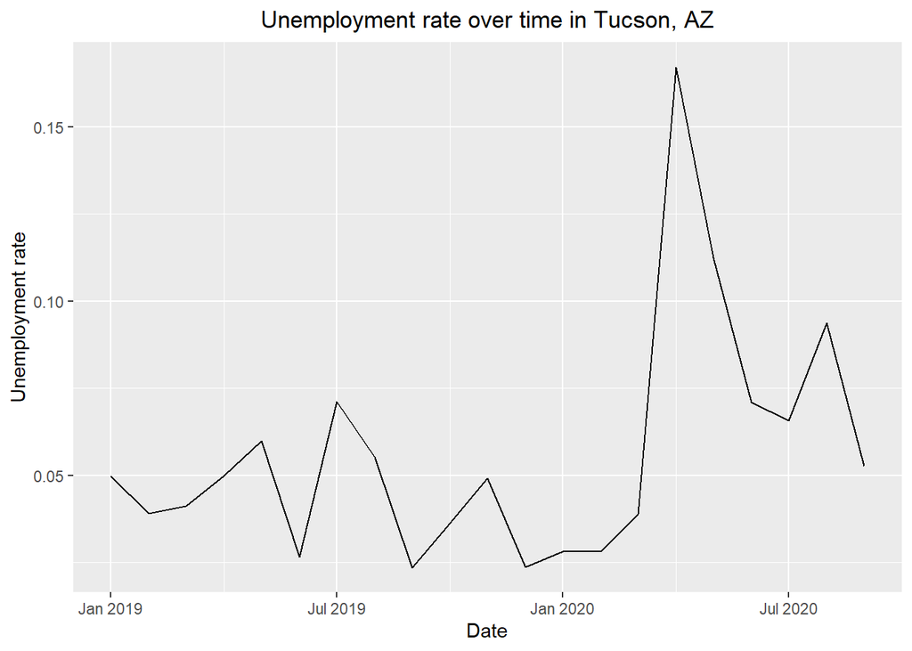

```r
# Tucson, AZ
data_cgf_loc %>%
  filter(location == "Tucson, AZ") %>%
  ggplot(mapping = aes(x = year_mon, y = unemp_rt)) + geom_line() +
  labs(x = "Date", y = "Unemployment rate",
       title = "Unemployment rate over time in Tucson, AZ") +
  theme(plot.title = element_text(hjust = 0.5))
```

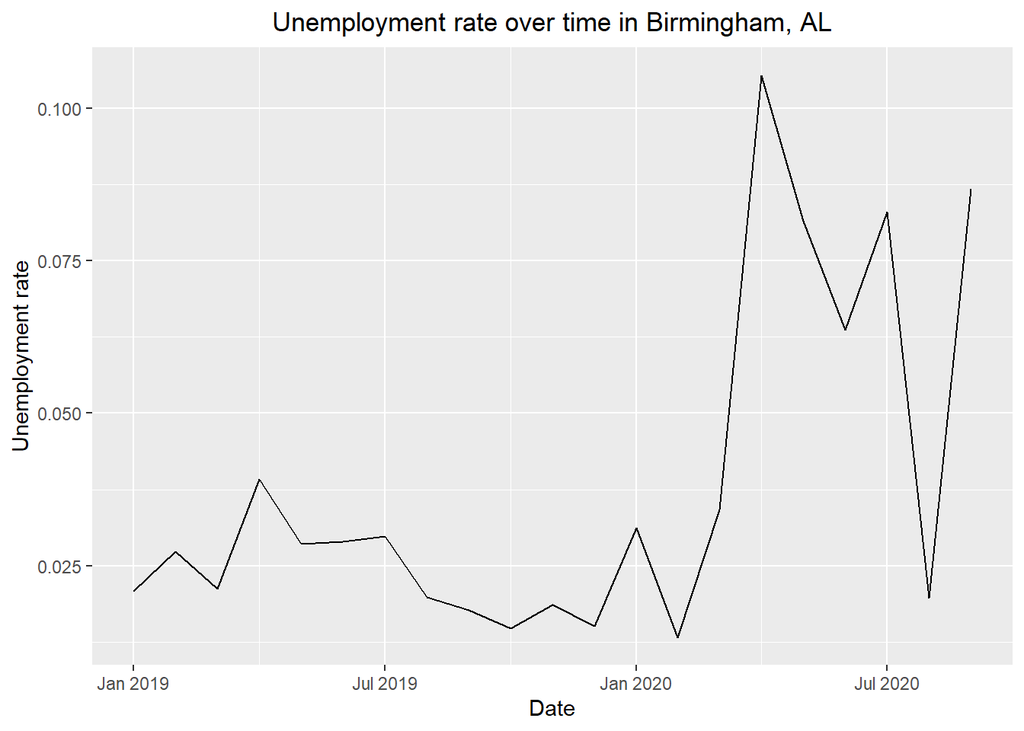

```r
# Birmingham, AL
data_cgf_loc %>%
  filter(location == "Birmingham-Hoover, AL") %>%
  ggplot(mapping = aes(x = year_mon, y = unemp_rt)) + geom_line() +
  labs(x = "Date", y = "Unemployment rate",
       title = "Unemployment rate over time in Birmingham, AL") +
  theme(plot.title = element_text(hjust = 0.5))
```

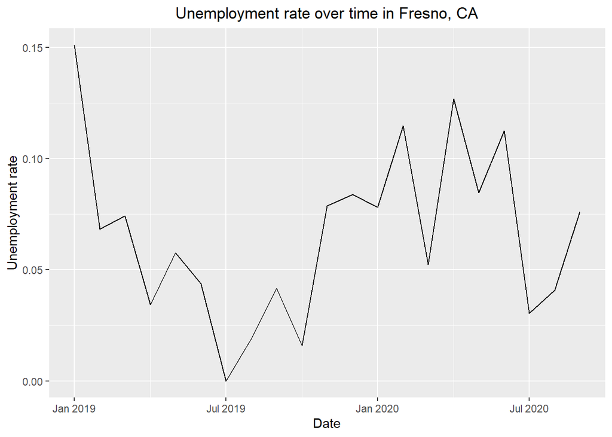

```r
# Fresno, CA
data_cgf_loc %>%
  filter(location == "Fresno, CA") %>%
  ggplot(mapping = aes(x = year_mon, y = unemp_rt)) + geom_line() +
  labs(x = "Date", y = "Unemployment rate",
       title = "Unemployment rate over time in Fresno, CA") +
  theme(plot.title = element_text(hjust = 0.5))
```

Create some time series variables

```r
# Focus on three month and six month rolling average
data_cgf_loc <- data_cgf_loc %>%
  ungroup() %>%
  group_by(location) %>%
  arrange(location, YEAR, MONTH) %>%
  mutate(lag1 = lag(x = unemp_rt, n = 1),
         lag2 = lag(x = unemp_rt, n = 2),
         lag3 = lag(x = unemp_rt, n = 3),
         lag4 = lag(x = unemp_rt, n = 4),
         lag5 = lag(x = unemp_rt, n = 5),
         avg3 = (unemp_rt + lag1 + lag2) / 3,
         avg6 = (unemp_rt + lag1 + lag2 + lag3 + lag4 + lag5) / 6
         )
```

Let’s see if the trends are a little smoother for `avg3` and `avg6` in the 3 cities that we visualized before

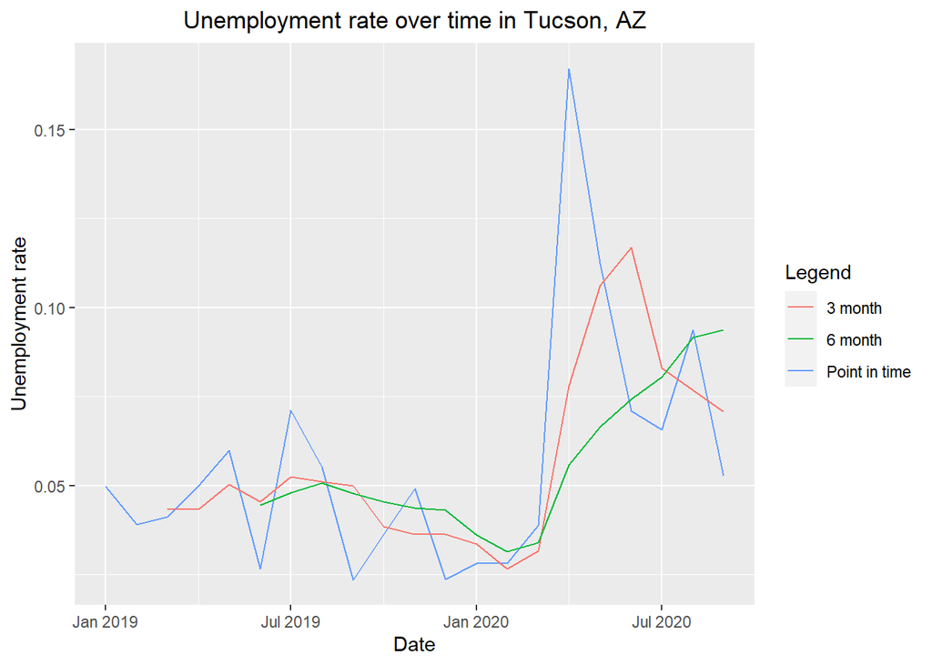

```r
# Tucson, AZ
data_cgf_loc %>%
  filter(location == "Tucson, AZ") %>%
  ggplot(mapping = aes(x = year_mon)) +
  geom_line(mapping = aes(y = unemp_rt, color = "Point in time")) +
  geom_line(mapping = aes(y = avg3, color = "3 month")) +
  geom_line(mapping = aes(y = avg6, color = "6 month")) +
  labs(x = "Date", y = "Unemployment rate",
       title = "Unemployment rate over time in Tucson, AZ",
       color = "Legend") +
  theme(plot.title = element_text(hjust = 0.5))
```

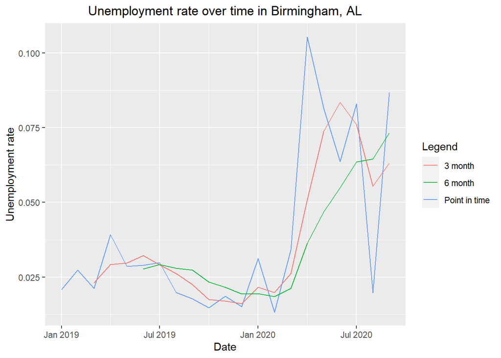

```r
# Birmingham, AL
data_cgf_loc %>%
  filter(location == "Birmingham-Hoover, AL") %>%
  ggplot(mapping = aes(x = year_mon)) +
  geom_line(mapping = aes(y = unemp_rt, color = "Point in time")) +
  geom_line(mapping = aes(y = avg3, color = "3 month")) +
  geom_line(mapping = aes(y = avg6, color = "6 month")) +
  labs(x = "Date", y = "Unemployment rate",
       title = "Unemployment rate over time in Birmingham, AL",
       color = "Legend") +
  theme(plot.title = element_text(hjust = 0.5))
```

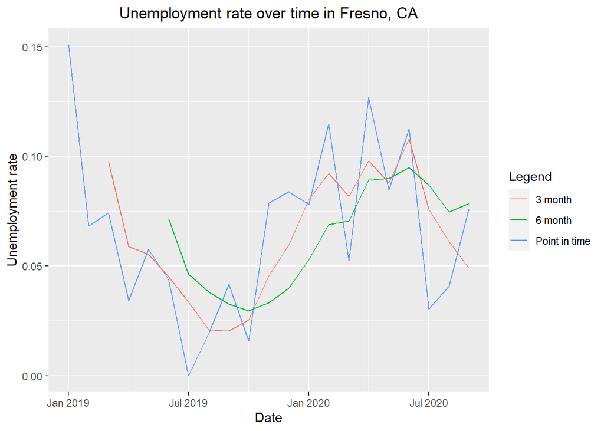

```r
# Fresno, CA
data_cgf_loc %>%
  filter(location == "Fresno, CA") %>%
  ggplot(mapping = aes(x = year_mon)) +
  geom_line(mapping = aes(y = unemp_rt, color = "Point in time")) +
  geom_line(mapping = aes(y = avg3, color = "3 month")) +
  geom_line(mapping = aes(y = avg6, color = "6 month")) +
  labs(x = "Date", y = "Unemployment rate",
       title = "Unemployment rate over time in Fresno, CA",
       color = "Legend") +
  theme(plot.title = element_text(hjust = 0.5))
```

Create variables that indicate changes in rolling average unemployment rate

```r
data_cgf_loc <- data_cgf_loc %>%
  mutate(diff1 = avg3 - lag(x = avg3, n = 1),
         diff3 = avg3 - lag(x = avg3, n = 3),
         diff6 = avg3 - lag(x = avg3, n = 6),
         diff12 = avg3 - lag(x = avg3, n = 12)
         )
```

Flag worst unemployment rate month for each location

```r
data_cgf_loc <- data_cgf_loc %>%
  mutate(worst_month = ifelse(avg3 == max(avg3, na.rm = T), 1, 0))
```

NOTE: I’ve noticed a non-negligible number of entries observations with a 3-month rolling average unemployment rate of 0. That’s certainly not ideal, and we may need to do some filtering going forward to remove those locations

```r
# Inspect locations that achieve a 3-month rolling average of zero unemployment
zeros <- data_cgf_loc %>%
  filter(avg3 == 0)
# While some of these may make sense (like heavy tourist towns), most are likely
# a result of poor data collection

# We'll create a flag for these locations and potentially exclude later on
data_cgf_loc <- data_cgf_loc %>%
  mutate(zero_unemp = ifelse(location %in% zeros$location, 1, 0))
```

At the peak of unemployment rates (for each location), which locations had the highest absolute unemployment rates? Highest increase in unemployment (over different time horizons)?

```r
# Highest unemployment at peak
data_cgf_loc %>%
  filter(worst_month == 1, YEAR == 2020, !is.na(avg6), zero_unemp == 0) %>%
  select(MONTH, location, unemp_rt, avg3, avg6, diff1, diff3, diff6, diff12) %>%
  arrange(desc(unemp_rt))
```

```
## # A tibble: 177 x 9
## # Groups:   location [177]
##       MONTH location           unemp_rt  avg3   avg6  diff1  diff3  diff6 diff12
##    <int+lb> <chr>                 <dbl> <dbl>  <dbl>  <dbl>  <dbl>  <dbl>  <dbl>
##  1 5 [May]  Muskegon-Norton S~    0.502 0.382 0.197  0.167  0.369  0.294  0.286
##  2 8 [Augu~ Atlantic City-Ham~    0.461 0.447 0.294  0.104  0.307  0.406  0.437
##  3 6 [June] Kahului-Wailuku-L~    0.352 0.407 0.213  0.114  0.388  0.379  0.402
##  4 8 [Augu~ Philadelphia-Camd~    0.347 0.189 0.144  0.0722 0.0887 0.0661 0.0981
##  5 6 [June] Chico, CA             0.302 0.228 0.166  0.0540 0.125  0.173  0.127
##  6 5 [May]  Chicago-Napervill~    0.262 0.186 0.169  0.0110 0.0326 0.137  0.146
##  7 6 [June] Boulder, CO           0.236 0.178 0.0982 0.0711 0.159  0.170  0.159
##  8 6 [June] Battle Creek, MI      0.229 0.240 0.126  0.0764 0.227  0.196  0.152
##  9 4 [Apri~ Monroe, LA            0.226 0.147 0.101  0.0316 0.0913 0.0818 0.101
## 10 8 [Augu~ Modesto, CA           0.217 0.162 0.144  0.0268 0.0356 0.0999 0.106
## # ... with 167 more rows
```

```r
# Highest 3 month increase in unemployment at peak
data_cgf_loc %>%
  filter(worst_month == 1, YEAR == 2020, !is.na(avg6), zero_unemp == 0) %>%
  select(MONTH, location, unemp_rt, avg3, avg6, diff1, diff3, diff6, diff12) %>%
  arrange(desc(diff3))
```

```
## # A tibble: 177 x 9
## # Groups:   location [177]
##        MONTH location             unemp_rt  avg3  avg6  diff1 diff3 diff6 diff12
##    <int+lbl> <chr>                   <dbl> <dbl> <dbl>  <dbl> <dbl> <dbl>  <dbl>
##  1 6 [June]  Kahului-Wailuku-Lah~    0.352 0.407 0.213 0.114  0.388 0.379  0.402
##  2 5 [May]   Muskegon-Norton Sho~    0.502 0.382 0.197 0.167  0.369 0.294  0.286
##  3 8 [Augus~ Atlantic City-Hammo~    0.461 0.447 0.294 0.104  0.307 0.406  0.437
##  4 6 [June]  Las Vegas-Paradise,~    0.190 0.276 0.162 0.0405 0.228 0.243  0.223
##  5 6 [June]  Battle Creek, MI        0.229 0.240 0.126 0.0764 0.227 0.196  0.152
##  6 6 [June]  Flint, MI               0.173 0.236 0.124 0.0577 0.225 0.183  0.225
##  7 6 [June]  Prescott, AZ            0.201 0.242 0.137 0.0531 0.211 0.223  0.203
##  8 6 [June]  Detroit-Warren-Dear~    0.181 0.222 0.132 0.0419 0.181 0.191  0.185
##  9 6 [June]  Rockford, IL            0.187 0.188 0.103 0.0622 0.172 0.170  0.158
## 10 5 [May]   Boston-Cambridge-Ne~    0.161 0.193 0.109 0.0474 0.167 0.163  0.176
## # ... with 167 more rows
```

```r
# Highest 12 month increase in unemployment at peak
data_cgf_loc %>%
  filter(worst_month == 1, YEAR == 2020, !is.na(avg6), zero_unemp == 0) %>%
  select(MONTH, location, unemp_rt, avg3, avg6, diff1, diff3, diff6, diff12) %>%
  arrange(desc(diff12))
```

```
## # A tibble: 177 x 9
## # Groups:   location [177]
##        MONTH location             unemp_rt  avg3  avg6  diff1 diff3 diff6 diff12
##    <int+lbl> <chr>                   <dbl> <dbl> <dbl>  <dbl> <dbl> <dbl>  <dbl>
##  1 8 [Augus~ Atlantic City-Hammo~    0.461 0.447 0.294 0.104  0.307 0.406  0.437
##  2 6 [June]  Kahului-Wailuku-Lah~    0.352 0.407 0.213 0.114  0.388 0.379  0.402
##  3 5 [May]   Muskegon-Norton Sho~    0.502 0.382 0.197 0.167  0.369 0.294  0.286
##  4 6 [June]  Flint, MI               0.173 0.236 0.124 0.0577 0.225 0.183  0.225
##  5 6 [June]  Las Vegas-Paradise,~    0.190 0.276 0.162 0.0405 0.228 0.243  0.223
##  6 6 [June]  Prescott, AZ            0.201 0.242 0.137 0.0531 0.211 0.223  0.203
##  7 6 [June]  York-Hanover, PA        0.216 0.212 0.144 0.0478 0.136 0.206  0.190
##  8 6 [June]  Detroit-Warren-Dear~    0.181 0.222 0.132 0.0419 0.181 0.191  0.185
##  9 5 [May]   Boston-Cambridge-Ne~    0.161 0.193 0.109 0.0474 0.167 0.163  0.176
## 10 6 [June]  Gainesville, FL         0.150 0.190 0.114 0.0338 0.151 0.154  0.175
## # ... with 167 more rows
```

Looking at September 2020 data, which locations are not doing significantly worse (or even better) on unemployment rate, relative to 12 months prior?

```r
data_cgf_loc %>%
  filter(YEAR == 2020, MONTH == 9, zero_unemp == 0) %>%
  select(MONTH, location, unemp_rt, avg3, avg6, diff1, diff3, diff6, diff12) %>%
  arrange(diff12)
```

```
## # A tibble: 213 x 9
## # Groups:   location [191]
##       MONTH location   unemp_rt   avg3   avg6    diff1    diff3    diff6  diff12
##    <int+lb> <chr>         <dbl>  <dbl>  <dbl>    <dbl>    <dbl>    <dbl>   <dbl>
##  1 9 [Sept~ Chicago-N~   0.0603 0.0827 0.0998 -1.21e-2 -0.0343  -0.0488  -0.0972
##  2 9 [Sept~ Fayettevi~   0.0773 0.0258 0.104   1.63e-2 -0.157   -0.0389  -0.0963
##  3 9 [Sept~ Chicago-N~   0.0896 0.0948 0.100  -2.07e-2 -0.0107  -0.0619  -0.0910
##  4 9 [Sept~ Muskegon-~   0.0415 0.0528 0.215  -2.22e-2 -0.325    0.0129  -0.0742
##  5 9 [Sept~ Chicago-N~   0.0983 0.115  0.122  -1.51e-3 -0.0122  -0.0479  -0.0593
##  6 9 [Sept~ Salisbury~   0.0706 0.0487 0.0499 -3.52e-4 -0.00242 -0.0180  -0.0570
##  7 9 [Sept~ Philadelp~   0.0450 0.0739 0.129  -2.72e-2 -0.111   -0.0424  -0.0532
##  8 9 [Sept~ Champaign~   0.0541 0.0315 0.0344  1.80e-2 -0.00585  0.00479 -0.0404
##  9 9 [Sept~ Philadelp~   0.0902 0.0831 0.0865  9.18e-3 -0.00674 -0.105   -0.0393
## 10 9 [Sept~ Colorado ~   0.0150 0.0314 0.0777 -3.24e-2 -0.0926  -0.0114  -0.0364
## # ... with 203 more rows
```

Save dataset to data folder that is easily accessible

```r
saveRDS(object = data_cgf_loc, file = "./../data/unemployment.RDS")
```

It turns out that we need to have county FIP code in order to merge with a different data source about COVID rates. I’ll now work on getting a version of the data that is grouped by county FIPS

```r
# Create grouped data frame
data_clean_county <- data_clean %>%
  filter(COUNTY != 0) %>%
  group_by(YEAR, MONTH, STATEFIP, COUNTY, METFIPS) %>%
  summarise(employed = sum(employed),
            labor_force = sum(lf_weighted),
            total_pop = sum(WTFINL))
# Calculate unemployment rate
data_clean_county <- data_clean_county %>%
  mutate(unemp_rt = 1 - employed / labor_force)

# Add columns
data_clean_county <- data_clean_county %>%
  ungroup() %>%
  group_by(COUNTY) %>%
  arrange(COUNTY, YEAR, MONTH) %>%
  mutate(lag1 = lag(x = unemp_rt, n = 1),
         lag2 = lag(x = unemp_rt, n = 2),
         lag3 = lag(x = unemp_rt, n = 3),
         lag4 = lag(x = unemp_rt, n = 4),
         lag5 = lag(x = unemp_rt, n = 5),
         avg3 = (unemp_rt + lag1 + lag2) / 3,
         avg6 = (unemp_rt + lag1 + lag2 + lag3 + lag4 + lag5) / 6,
         diff1 = avg3 - lag(x = avg3, n = 1),
         diff3 = avg3 - lag(x = avg3, n = 3),
         diff6 = avg3 - lag(x = avg3, n = 6),
         diff12 = avg3 - lag(x = avg3, n = 12),
         worst_month = ifelse(avg3 == max(avg3, na.rm = T), 1, 0)
         )

# Inspect locations that achieve a 3-month rolling average of zero unemployment
zeros <- data_clean_county %>%
  filter(avg3 == 0)
# While some of these may make sense (like heavy tourist towns), most are likely
# a result of poor data collection

# We'll create a flag for these locations and potentially exclude later on
data_clean_county <- data_clean_county %>%
  mutate(zero_unemp = ifelse(COUNTY %in% zeros$COUNTY, 1, 0))

# Add location
# Join data sets
data_clean_county <- left_join(x = data_clean_county, y = fips_cw, by = "METFIPS")

# Create a single date column
data_clean_county <- data_clean_county %>%
  mutate(year_mon = as.yearmon(paste(YEAR, MONTH), "%Y %m"))

# Save data
saveRDS(object = data_clean_county, file = "./../data/unemployment_county.RDS")
```

```r
# Load COVID data
covid_data <- readRDS("./../data/county_rates.rds")

# Group COVID data
covid_group <- covid_data %>%
  group_by(county_name, countyFIPS, stateFIPS, year, month) %>%
  summarise(pop = mean(population),
            cases = max(cases),
            death = max(deaths)) %>%
  mutate(COUNTY = countyFIPS,
         MONTH = month)
# Combine COVID and unemployment data. Filter for only 2020
unemp_covid <- left_join(x = data_clean_county, y = covid_group,
                         by = c("COUNTY", "MONTH")) %>%
  filter(YEAR == 2020)
```

Next, we obtain data relating to government policies in each state.

```r
# For description of variables:
# https://github.com/OxCGRT/covid-policy-tracker/blob/master/documentation/codebook.md
url <- "https://raw.githubusercontent.com/OxCGRT/covid-policy-tracker/master/data/OxCGRT_latest.csv"

raw_data <- read.csv(url)

# clean names and dates
clean_data <- raw_data %>%
  janitor::clean_names() %>%
  mutate(date = ymd(date)) %>%
  select(-contains("flag"),
         -m1_wildcard)

# further clean variable names
names(clean_data)[6:23] <- substring(names(clean_data)[6:23], 4)

# country-level data
# world_data <- clean_data %>%
#   filter(region_name == "") %>%
#   select(-contains("region"))

# state-level data
state_data <- clean_data %>%
  filter(country_code == "USA",
         region_code  != "") %>%
  select(-c("country_name",
            "country_code")) %>%
  rename(state = region_name)
```

Save state policy data.

```r
saveRDS(state_data, "./../data/policies.rds")
```

Now that we have collected all of the data relevant to our project, we combine it into a single entity.

```r
uemp_data <- readRDS("./../data/unemp_covid.rds")

uemp_data <- uemp_data %>%
  janitor::clean_names()

# convert city to full state name
city_to_state <- function(x) {
  # get state abbreviation from city var
  state_abb <- str_sub(x, -2)
  abb_ind <- which(state.abb == state_abb)

  return(state.name[abb_ind])
}

# convert metfips to state name
fips_to_state <- function(x) {
  fips_ind <- which(fips_code == as.character(x))
  city <- fips_location[fips_ind]

  if(is.null(city)) {
    return(NA)
  } else {
    return(city_to_state(city))
  }
}

# add state column and clean a bit
uemp_data <- remove_all_labels(uemp_data) %>%
  mutate(state = map(metfips, fips_to_state)) %>%
  unnest(cols = c(state))

uemp_data_2020 <- uemp_data %>%
  filter(grepl("2020", year_mon, fixed = TRUE)) %>%
  mutate(year_mon = as.character(year_mon))

state_data_tc <- state_data %>%
  mutate(
    year_mon = paste(month(date, label = TRUE), year(date))
  ) %>%
  select(year_mon,
         state,
         stringency_index,
         government_response_index,
         economic_support_index,
         containment_health_index) %>%
  group_by(year_mon, state) %>%
  summarise(
    mean_stringency_index = mean(
      stringency_index,
      na.rm = TRUE
    ),
    mean_government_response_index = mean(
      government_response_index,
      na.rm = TRUE
    ),
    mean_economic_support_index    = mean(
      economic_support_index,
      na.rm = TRUE
    ),
    mean_containment_health_index  = mean(
      containment_health_index,
      na.rm = TRUE
    ))
combined_data <- inner_join(uemp_data_2020, state_data_tc,
                            by = c("state", "year_mon"))
```

Save the combined data.

```r
saveRDS(combined_data, "./../data/combined.rds")
```

Load combined data, and add a few quick features for changes in COVID info

```r
# Add some time series relevant data for the COVID info
combined_data <- combined_data %>%
  group_by(county_fips) %>%
  mutate(case_rt = cases / pop,
         death_rt = death / pop,
         covid_lag1 = lag(x = cases, n = 1),
         covid_lag3 = lag(x = cases, n = 3),
         covid_lag6 = lag(x = cases, n = 6),
         covid_abs_1 = cases - lag(x = cases, n = 1),
         covid_abs_3 = cases - lag(x = cases, n = 3),
         covid_abs_6 = cases - lag(x = cases, n = 6),
         covid_perc_1 = ifelse(covid_lag1 == 0, NA, covid_abs_1 / covid_lag1),
         covid_perc_3 = ifelse(covid_lag3 == 0, NA, covid_abs_3 / covid_lag3) / 3,
         covid_perc_6 = ifelse(covid_lag6 == 0, NA, covid_abs_6 / covid_lag6)
         )

# Produce the final data set for clustering
clustering <- combined_data %>%
  ungroup() %>%
  filter(year == 2020, month == 9, zero_unemp == 0) %>%
  select(county_name,
         avg3, avg6, diff1, diff3, diff6, diff12,
         mean_stringency_index, mean_government_response_index,
         mean_economic_support_index, mean_containment_health_index,
         case_rt, death_rt, covid_perc_1, covid_perc_3)
```

Save data for clustering

```r
saveRDS(object = clustering, file = "./../data/clustering.RDS")
```

Scale data for k-means clustering analysis.

```r
set.seed(8675309)

data <- clustering %>%
  select(-county_name) %>%
  scale()
```

Check for optimal number of clusters.

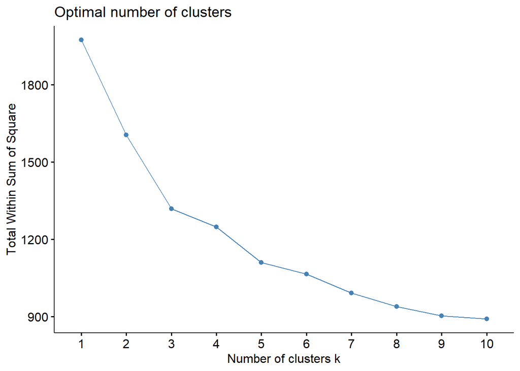

```r
fviz_nbclust(data, kmeans, method = "wss")
```

Higher numbers of clusters further minimize the within cluster sum of squares, but 3 clusters is adequate and simplifies our analysis. Now we perform the clustering analysis.

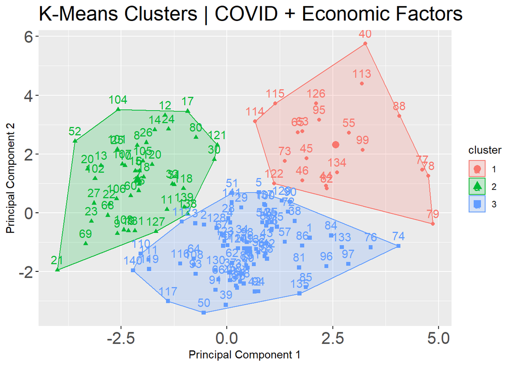

```r
km.res <- kmeans(data, 3, nstart = 100)

fviz_cluster(km.res, data) +
  labs(x = "Principal Component 1",
       y = "Principal Component 2",
       title = "K-Means Clusters | COVID + Economic Factors") +
  theme(plot.title = element_text(size = 20),
        axis.text = element_text(size = 16))
```

```r
print(km.res)
```

```
## K-means clustering with 3 clusters of sizes 21, 44, 77
##
## Cluster means:
##         avg3         avg6       diff1       diff3       diff6     diff12
## 1  1.5371300  1.525331141 -0.58774187 -0.03338797  1.54475025  1.4146552
## 2  0.2530083  0.003871766  0.33161525  0.36252426 -0.07595374  0.2655114
## 3 -0.5637935 -0.418211840 -0.02920119 -0.19805091 -0.37789338 -0.5375359
##   mean_stringency_index mean_government_response_index
## 1            -0.5798702                     -0.6461772
## 2             1.0566402                      1.2644919
## 3            -0.4456480                     -0.5463367
##   mean_economic_support_index mean_containment_health_index    case_rt
## 1                  -0.5942986                    -0.5297067  0.4312911
## 2                   0.9132966                     1.1647685 -0.4542869
## 3                  -0.3598023                    -0.5211166  0.1419677
##      death_rt covid_perc_1 covid_perc_3
## 1  0.89482765 -0.404240018  -0.28853617
## 2 -0.51883987  0.002350987   0.24008085
## 3  0.05243602  0.108903857  -0.05849737
##
## Clustering vector:
##   [1] 3 3 3 3 3 2 2 2 2 2 2 2 2 2 2 2 2 2 2 2 2 2 2 2 2 2 2 3 3 2 2 2 3 3 3 3 3
##  [38] 3 3 1 3 3 3 1 1 1 3 3 3 3 3 2 3 3 1 3 3 3 3 2 3 3 1 3 1 3 3 2 2 3 3 3 1 3
##  [75] 3 3 1 1 1 2 3 1 3 3 3 3 3 1 3 3 3 3 3 3 1 3 3 3 1 3 2 2 2 2 2 2 2 3 3 3 3
## [112] 3 1 1 1 3 3 2 3 2 2 1 3 3 3 1 2 3 3 3 2 3 3 1 3 3 3 2 2 3 3 3
##
## Within cluster sum of squares by cluster:
## [1] 224.4385 419.8978 674.2333
##  (between_SS / total_SS =  33.2 %)
##
## Available components:
##
## [1] "cluster"      "centers"      "totss"        "withinss"     "tot.withinss"
## [6] "betweenss"    "size"         "iter"         "ifault"
```

View members of clusters close to centroids.

```r
clustering[c(18, 55, 41),]
```

```
## # A tibble: 3 x 15
##   county_name   avg3   avg6   diff1   diff3  diff6 diff12 mean_stringency~
##   <chr>        <dbl>  <dbl>   <dbl>   <dbl>  <dbl>  <dbl>            <dbl>
## 1 San Mateo ~ 0.0917 0.120  -0.0256 -0.0565 0.0535 0.0601             64.4
## 2 Lake County 0.166  0.196  -0.0367 -0.0605 0.125  0.133              51.6
## 3 Hillsborou~ 0.0511 0.0694 -0.0300 -0.0366 0.0210 0.0128             55.6
## # ... with 7 more variables: mean_government_response_index <dbl>,
## #   mean_economic_support_index <dbl>, mean_containment_health_index <dbl>,
## #   case_rt <dbl>, death_rt <dbl>, covid_perc_1 <dbl>, covid_perc_3 <dbl>
```